# R Notebook

# Implementing reproducibility

In this exercise the idea is for you to create a totally reproducible analysis using R Notebook or R markdown. For that you will use as basis the R commands that I am giving here, add your own comments (if you don’t know what a command does use help or google or me), add some markdown formatting and knit this as html. Then create a repository online, with the data and the scripts so that another group can then repeat your analyses.

Don’t forget to comment and add information, and please do not copy my indications, as that defeats the purpose of the exercise

Your scientific question is:

**Does adaptation to laboratory decrease plasticity?**

The data set corresponds to populations of Drosophila subobscura that come from 3 different locations Ad (Adraga, Portugal), Mo (Montpellier, France), Gro (Groningen, Netherlands) that were introduced in the laboratory. They have spent 28 generations in new laboratory conditions. Each population was replicated 3 times after foundation, having 3 independent replicates evolving in the same conditions.

The TA population is the control population, already adapted to the laboratory.

To test if plasticity changed throughout adaptation to the same environment you have to:

- Import the data
- Do an ANOVA to test if there are differences between temperature across generations for each population
- Create a plot per population

## Importing libraries

```r
library(ggplot2)
#install.packages("dplyr")
library(dplyr)
#install.packages("car")
library(car)
```

## Data

Lets import the file and check the structure

```r
temperature<- read.csv("./Fec_3T.csv", header=TRUE, na.strings = "MV")

str(temperature)
```

[output not shown]

## Creating a data set per population

This makes it easier to analyse the data

```r
ad<-subset(temperature, Regime=="Ad")
gro<-subset(temperature, Regime=="Gro")
mo<-subset(temperature, Regime=="Mo")
```

## Testing differences between generations across temperatures

```r
### Ad
modelAd<-lm(Fecundity~Generation*Temperature, data=ad)

summary(modelAd)
Anova(modelAd)

#### Gro

modelGro<-lm(Fecundity~Generation*Temperature, data=gro)

summary(modelGro)
Anova(modelGro)

#### Mo
modelMo<-lm(Fecundity~Generation*Temperature, data=mo)

summary(modelMo)
Anova(modelMo)
```

[output not shown]

Do you see any differences between the generation in plasticity?

## How does plasticity change throughout time?

Here we will see a plot of how plasticity changes through time, for each regime.

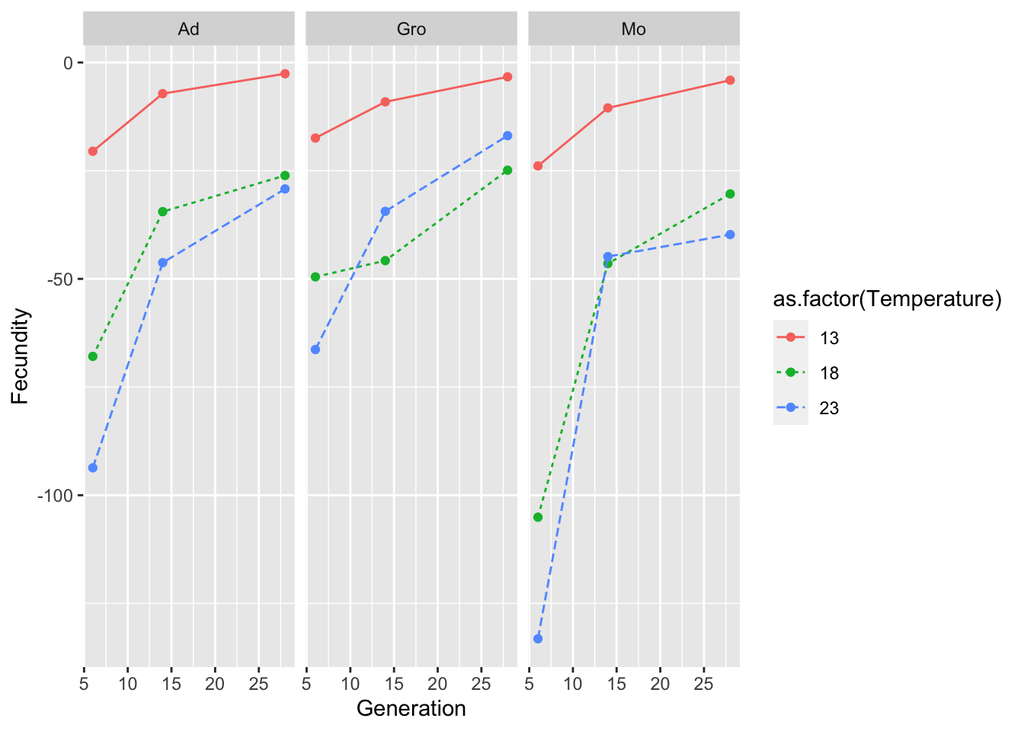

```r
plot_temp<-ggplot(temperature, aes(x=Generation, y=Fecundity, color=as.factor(Temperature), linetype=as.factor(Temperature)))+
  facet_grid(.~Regime)+
  geom_point()+
  geom_line()

plot_temp
```

```r
#export the figure
ggsave( "./Figure1.pdf")
```

What can you conclude?

Don’t forget to give comments on the code (even if its just what it is doing)! and add some conclusions about it.

**Don’t forget to create the repository and put all relevant files there**